# project_draft

```python
import pandas as pd
import matplotlib.pyplot as plt
import numpy as np
from IPython.display import display, HTML
import warnings
import folium
import json
warnings.filterwarnings('ignore')
```

First we load the data

```python
panama_entity = pd.read_csv('./Data/panama_papers.nodes.entity.csv')
```

```python
## Any duplicated row?
panama_entity[panama_entity.duplicated()==True].shape[0]
# no duplicate row

## Features:
panama_entity.columns

## Convert feature:'n.incorporation_date' to type date
panama_entity['n.incorporation_date'] = pd.to_datetime(panama_entity['n.incorporation_date'])
# this conversion is essential, it let us do sorting.
```

- **Dataset Size:**
  - rows: 213634
  - features: 18
- **'labels(n)':** "Entity"
- **'n.valid_until':** 'The Panama Papers data is current through 2015'
- **'n.country_codes':** 159 countries'code (exp: HKG for Hong Kong)
- **'n.countries':** 159 countries'fullname
- **'n.node_id':** node'id
- **'n.sourceID':** 'Panama Papers'
- **'n.address':** 18602 adress
- **'n.name':** 206525 names
- **'n.jurisdiction_description':** 21 jurisdictions'name

```python
panama_entity['n.jurisdiction_description'].unique()
```

```
array(['Samoa', 'Panama', 'Nevada', 'United Kingdom', 'Singapore',
       'Ras Al Khaimah', 'Isle Of Man', 'British Anguilla', 'Seychelles',
       'Niue', 'Uruguay', 'British Virgin Islands', 'Hong Kong',
       'New Zealand', 'Bahamas', 'Cyprus', 'Malta', 'Belize', 'Jersey',
       'Wyoming', 'Costa Rica'], dtype=object)
```

- **'n.service_provider':** 'Mossack Fonseca'
- **'n.jurisdiction':** 21 jurisdictions'code
- **'n.closed_date':** NaN
- **'n.incorporation_date':** 9493 incorporation'date between ['1936','2015']
- **'n.ibcRUC':** 120046
- **'n.type':** NaN
- **'n.status':** Status
- **'n.company_type':** NaN
- **'n.note':** Notes

We make some plot to help us understand the data.

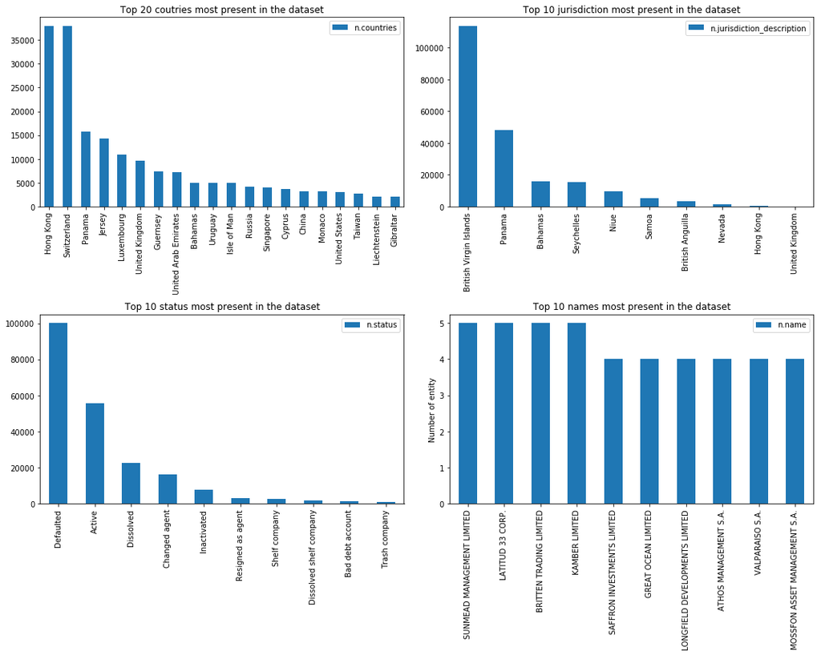

```python
fig, axes = plt.subplots(nrows=2, ncols=2, figsize=(15,12))


countries = pd.DataFrame(panama_entity['n.countries'].value_counts())
countries[:20].plot(kind='bar',title='Top 20 coutries most present in the dataset',ax=axes[0,0])
plt.ylabel('Number of entity')

jurisdiction = pd.DataFrame(panama_entity['n.jurisdiction_description'].value_counts())
jurisdiction[:10].plot(kind='bar',title='Top 10 jurisdiction most present in the dataset',ax=axes[0,1])
plt.ylabel('Number of entity')

status = pd.DataFrame(panama_entity['n.status'].value_counts())
status[:10].plot(kind='bar',title='Top 10 status most present in the dataset',ax=axes[1,0])
plt.ylabel('Number of entity')

names = pd.DataFrame(panama_entity['n.name'].value_counts())
names[:10].plot(kind='bar',title='Top 10 names most present in the dataset',ax=axes[1,1])
plt.ylabel('Number of entity')

plt.tight_layout()

plt.show()
```

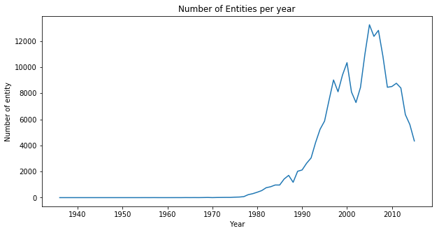

```python
year = pd.DataFrame(panama_entity['n.incorporation_date'].dropna().dt.year.astype(int).value_counts())
plt.figure(figsize=(10,5))
plt.plot(year['n.incorporation_date'].sort_index())
plt.xlabel('Year')
plt.ylabel('Number of entity')
plt.title('Number of Entities per year')
plt.show()
```

As we can see the curve are sensitives to some historical events. Let's try to understand which one.

# 1935 - 1960 Before the financial secrecy

The coutry hadn't have almost any offshore's entites

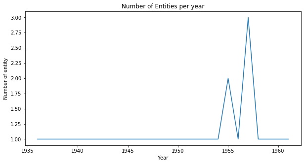

```python
plt.figure(figsize=(10,5))
plt.plot(year['n.incorporation_date'].sort_index()[:10])
plt.xlabel('Year')
plt.ylabel('Number of entity')
plt.title('Number of Entities per year')
plt.show()
```

# 1960-2000 The beginning of corporate and individual financial secrecy

The small decrease is due to the american invasion of the US invasion of panama

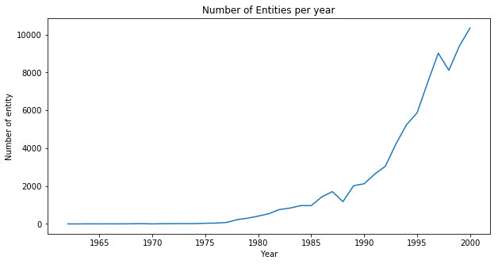

```python
plt.figure(figsize=(10,5))
plt.plot(year['n.incorporation_date'].sort_index()[10:49])
plt.xlabel('Year')
plt.ylabel('Number of entity')
plt.title('Number of Entities per year')
plt.show()
```

# 2000-2005 The OECD report effect on Panama

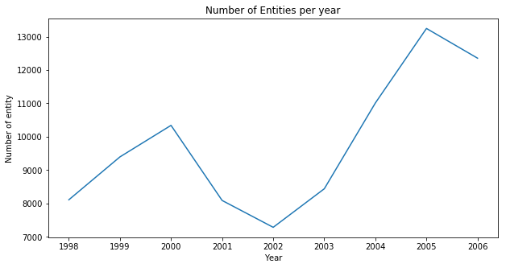

```python
plt.figure(figsize=(10,5))
plt.plot(year['n.incorporation_date'].sort_index()[46:55])
plt.xlabel('Year')
plt.ylabel('Number of entity')
plt.title('Number of Entities per year')
plt.show()
```

# The subprime crisis

The crisis has a terrrible effect on the Panama and 4000 entity left the country

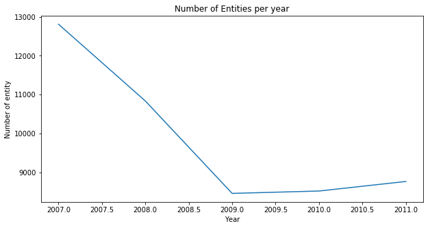

```python
plt.figure(figsize=(10,5))
plt.plot(year['n.incorporation_date'].sort_index()[55:60])
plt.xlabel('Year')
plt.ylabel('Number of entity')
plt.title('Number of Entities per year')
plt.show()
```

# The after crisis and the Panama Paper's crisis

The number of entities continue to decrease and in 2015 the Panama papers are leaked and the world discovered it.

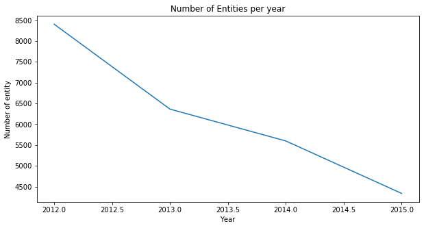

```python
plt.figure(figsize=(10,5))
plt.plot(year['n.incorporation_date'].sort_index()[60:])
plt.xlabel('Year')
plt.ylabel('Number of entity')
plt.title('Number of Entities per year')
plt.show()
```

**At year 2005, there was almost 13246 entities but something happened which decreased number of entities after this year**

```python
evolution_feature_year = panama_entity[['n.incorporation_date','n.countries','n.jurisdiction_description','n.status']]
evolution_feature_year.dropna(subset = ['n.incorporation_date'], inplace=True)
evolution_feature_year['n.incorporation_date'] = evolution_feature_year['n.incorporation_date'].dt.year.astype(int)
evolution_feature_year['count'] = 1
```

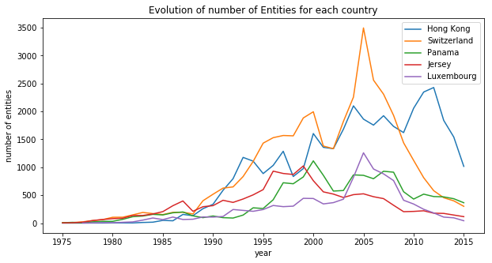

```python
top5_countries = countries[:5].index.tolist()
countries_year = evolution_feature_year[evolution_feature_year['n.countries'].isin(top5_countries)][['n.incorporation_date','n.countries','count']]
countries_year = countries_year.groupby(['n.incorporation_date','n.countries']).count().reset_index()

plt.figure(figsize=(10,5))
for country in top5_countries:
    data = countries_year[countries_year['n.countries']==country]
    data = data[data['n.incorporation_date']>=1975]
    plt.plot(data['n.incorporation_date'],data['count'])

plt.legend(top5_countries)
plt.xlabel('year')
plt.ylabel('number of entities')
plt.title('Evolution of number of Entities for each country')
plt.show()
```

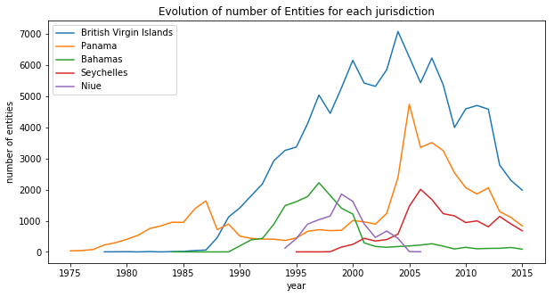

```python
top5_jurisdiction = jurisdiction[:5].index.tolist()
jurisdiction_year = evolution_feature_year[evolution_feature_year['n.jurisdiction_description'].isin(top5_jurisdiction)][['n.incorporation_date','n.jurisdiction_description','count']]
jurisdiction_year = jurisdiction_year.groupby(['n.incorporation_date','n.jurisdiction_description']).count().reset_index()

plt.figure(figsize=(10,5))
for jd in top5_jurisdiction:
    data = jurisdiction_year[jurisdiction_year['n.jurisdiction_description']==jd]
    data = data[data['n.incorporation_date']>=1975]
    plt.plot(data['n.incorporation_date'],data['count'])

plt.legend(top5_jurisdiction)
plt.xlabel('year')
plt.ylabel('number of entities')
plt.title('Evolution of number of Entities for each jurisdiction')
plt.show()
```

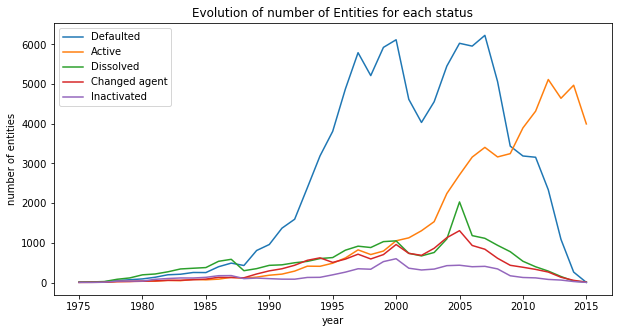

```python
top5_status = status[:5].index.tolist()
status_year = evolution_feature_year[evolution_feature_year['n.status'].isin(top5_status)][['n.incorporation_date','n.status','count']]
status_year = status_year.groupby(['n.incorporation_date','n.status']).count().reset_index()

plt.figure(figsize=(10,5))
for st in top5_status:
    data = status_year[status_year['n.status']==st]
    data = data[data['n.incorporation_date']>=1975]
    plt.plot(data['n.incorporation_date'],data['count'])

plt.legend(top5_status)
plt.xlabel('year')
plt.ylabel('number of entities')
plt.title('Evolution of number of Entities for each status')
plt.show()
```

```python
world_geo_path = './data/map.json'

with open(world_geo_path) as json_file:
    json_data = json.load(json_file)
countries_geo = pd.DataFrame(json_data)
countries_geo['x'] = (countries_geo['north'].astype(float) + countries_geo['south'].astype(float)) /2
countries_geo['y'] = (countries_geo['east'].astype(float) + countries_geo['west'].astype(float)) /2
countries_geo = countries_geo[['country','x','y']]
countries_geo.set_index('country',inplace=True)
```

```python
world_map = folium.Map([20,0], tiles='cartodbpositron', zoom_start=2)


entity_by_country = pd.DataFrame(panama_entity['n.countries'].value_counts())
entity_by_country.reset_index(inplace=True)
entity_by_country.columns = ['Country','count']
entity_by_country = entity_by_country[:30]

for i in range(0,len(entity_by_country)):
    country = entity_by_country.iloc[i]['Country']
    folium.CircleMarker(
      location=[countries_geo.ix[country]['x'], countries_geo.ix[country]['y']],
      popup=country+": "+str(entity_by_country.iloc[i]['count'])+" Entities",
      radius= entity_by_country.iloc[i]['count'].astype(float)/1000,
      color='blue',
      fill=True,
      fill_color='blue'

   ).add_to(world_map)
world_map
```

[interactive chart not shown]

## Officer

```python
panama_officer = pd.read_csv('./Data/panama_papers.nodes.officer.csv')
```

```python
# no duplicated row
panama_officer[panama_officer.duplicated()==True].shape[0]
```

```
0
```

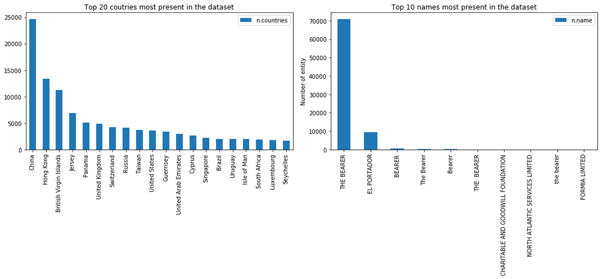

```python
fig, axes = plt.subplots(nrows=1, ncols=2, figsize=(15,7))


countries = pd.DataFrame(panama_officer['n.countries'].value_counts())
countries[:20].plot(kind='bar',title='Top 20 coutries most present in the dataset',ax=axes[0])
plt.ylabel('Number of entity')

names = pd.DataFrame(panama_officer['n.name'].value_counts())
names[:10].plot(kind='bar',title='Top 10 names most present in the dataset',ax=axes[1])
plt.ylabel('Number of entity')

plt.tight_layout()

plt.show()
```

**The second plot is showing something weird with names "BEARER" & "EL PORTADOR" which lead us to some interresting facts...**

[figure not shown]

```python
fig, axes = plt.subplots(nrows=1, ncols=1, figsize=(15,5), squeeze=False)

names = pd.DataFrame(panama_officer[panama_officer['n.name'].str.contains('bearer|EL PORTADOR', case=False) == False ]['n.name'].value_counts())
names[:40].plot(kind='bar',title='Top 10 names most present in the dataset',ax=axes[0,0])
plt.ylabel('Number of entity')

plt.show()
```

```python
pd.DataFrame(panama_officer[panama_officer['n.name'].str.contains('bearer', case=False) == True ]['n.name'].unique(),columns=['Names']).head()
```

|  | Names |
| --- | --- |
| 0 | THE BEARER |
| 1 | THE BEARER (MR. PAUL SPECK) |
| 2 | THE BEARER (EURO) |
| 3 | BEARER |
| 4 | the bearer |

```python
world_map = folium.Map([20,0], tiles='cartodbpositron', zoom_start=2)


world_geo_path = r'./data/world_map.geojson'

officer_by_country = pd.DataFrame(panama_officer['n.countries'].value_counts())
officer_by_country.reset_index(inplace=True)
officer_by_country.columns = ['Country','count']

world_map.choropleth(geo_data=world_geo_path, data=officer_by_country,
             columns=['Country','count'],
             key_on='feature.properties.name',
             fill_color='OrRd', fill_opacity=0.7, line_opacity=0.5,
             highlight=True,
             legend_name='Number of Officer')
world_map
```

[interactive chart not shown]

## Intermediary

```python
panama_intermediary = pd.read_csv('./Data/panama_papers.nodes.intermediary.csv')
```

```python
# no duplicated row
panama_intermediary[panama_intermediary.duplicated()==True].shape[0]
```

```
0
```

```python
panama_intermediary.shape
```

```
(14110, 18)
```

```python
panama_intermediary.head(n=2)
```

|  | labels(n) | n.valid_until | n.country_codes | n.countries | n.node_id | n.sourceID | n.address | n.name | n.jurisdiction_description | n.service_provider | n.jurisdiction | n.closed_date | n.incorporation_date | n.ibcRUC | n.type | n.status | n.company_type | n.note |
| --- | --- | --- | --- | --- | --- | --- | --- | --- | --- | --- | --- | --- | --- | --- | --- | --- | --- | --- |
| 0 | ["Intermediary"] | The Panama Papers data is current through 2015 | ZAF | South Africa | 11000001 | Panama Papers | MICHAEL PAPAGEORGE; MR. 106 NICHOLSON STREET B... | MICHAEL PAPAGEORGE, MR. | NaN | NaN | NaN | NaN | NaN | NaN | NaN | ACTIVE | NaN | NaN |
| 1 | ["Intermediary"] | The Panama Papers data is current through 2015 | LIE | Liechtenstein | 11000002 | Panama Papers | NaN | CORFIDUCIA ANSTALT | NaN | NaN | NaN | NaN | NaN | NaN | NaN | ACTIVE | NaN | NaN |

[figure not shown]

```python
fig, axes = plt.subplots(nrows=1, ncols=2, figsize=(15,5))


countries = pd.DataFrame(panama_intermediary['n.countries'].value_counts())
countries[:10].plot(kind='bar',title='Top 20 coutries most present in the dataset',ax=axes[0])
plt.ylabel('Number of entity')

status = pd.DataFrame(panama_intermediary['n.status'].value_counts())
status[:5].plot(kind='bar',title='Top 10 status most present in the dataset',ax=axes[1])
plt.ylabel('Number of entity')

plt.tight_layout()

plt.show()
```

```python
names = pd.DataFrame(panama_intermediary['n.name'].value_counts())
names[:4]
```

|  | n.name |
| --- | --- |
| WILDGEN & PARTNERS | 2 |
| COMPANHIA DE NAVEGAÇÃO NORSUL | 2 |
| FERNANDEZ G., JUAN ANTONIO | 2 |
| ENRIQUE O. GRISANTI | 2 |

```python
geo_data = countries.reset_index()
geo_data.columns =['Country','count']
geo_data = geo_data[~geo_data['Country'].str.contains(';')]
geo_data = geo_data[:50]
```

```python
world_geo_path = './data/map.json'

with open(world_geo_path) as json_file:
    json_data = json.load(json_file)
countries_geo = pd.DataFrame(json_data)
countries_geo['x'] = (countries_geo['north'].astype(float) + countries_geo['south'].astype(float)) /2
countries_geo['y'] = (countries_geo['east'].astype(float) + countries_geo['west'].astype(float)) /2
countries_geo = countries_geo[['country','x','y']]
countries_geo.set_index('country',inplace=True)
```

```python
world_map = folium.Map([20,0], tiles='cartodbpositron', zoom_start=2)

for i in range(0,len(geo_data)):
    country = geo_data.iloc[i]['Country']
    folium.CircleMarker(
      location=[countries_geo.ix[country]['x'], countries_geo.ix[country]['y']],
      popup=country+": "+str(geo_data.iloc[i]['count']),
      radius= geo_data.iloc[i]['count'].astype(float)/50,
      color='crimson',
      fill=True,
      fill_color='crimson'

   ).add_to(world_map)
world_map
```

[interactive chart not shown]

## Adress

```python
panama_adress = pd.read_csv('./Data/panama_papers.nodes.address.csv')
```

```python
# no duplicated row
panama_adress[panama_adress.duplicated()==True].shape[0]
```

```
0
```

```python
panama_adress.shape
```

```
(93454, 18)
```

```python
panama_adress.head(n=2)
```

|  | labels(n) | n.valid_until | n.country_codes | n.countries | n.node_id | n.sourceID | n.address | n.name | n.jurisdiction_description | n.service_provider | n.jurisdiction | n.closed_date | n.incorporation_date | n.ibcRUC | n.type | n.status | n.company_type | n.note |
| --- | --- | --- | --- | --- | --- | --- | --- | --- | --- | --- | --- | --- | --- | --- | --- | --- | --- | --- |
| 0 | ["Address"] | The Panama Papers data is current through 2015 | SGP | Singapore | 14000001 | Panama Papers | -\t27 ROSEWOOD DRIVE #16-19 SINGAPORE 737920 | NaN | NaN | NaN | NaN | NaN | NaN | NaN | NaN | NaN | NaN | NaN |
| 1 | ["Address"] | The Panama Papers data is current through 2015 | KAZ | Kazakhstan | 14000002 | Panama Papers | "Almaly Village" v.5, Almaty Kazakhstan | NaN | NaN | NaN | NaN | NaN | NaN | NaN | NaN | NaN | NaN | NaN |

## Edges

```python
panama_edges = pd.read_csv('./Data/panama_papers.edges.csv')
```

```python
## Duplicated row: 8
panama_edges.drop(panama_edges[panama_edges.duplicated()==True].index,inplace=True)
```

- **Dataset Size:**
  - relations: 674094
  - features: 7
- **'node_1':** nodeId 1
- **'node_2':** nodeId 2
- **'r.sourceID':** Panama Papers
- **'r.valid_until':** The Panama Papers data is current through 2015
- **'rel_type':** relation type

```python
panama_edges['rel_type'].unique()
```

```
array(['registered_address', 'intermediary_of', 'officer_of'], dtype=object)
```

```python
panama_edges.head()
```

|  | node_1 | rel_type | node_2 | r.sourceID | r.valid_until | r.start_date | r.end_date |
| --- | --- | --- | --- | --- | --- | --- | --- |
| 0 | 10000035 | registered_address | 14095990 | Panama Papers | NaN | NaN | NaN |
| 1 | 10000044 | registered_address | 14091035 | Panama Papers | NaN | NaN | NaN |
| 2 | 10000055 | registered_address | 14095990 | Panama Papers | NaN | NaN | NaN |
| 3 | 10000064 | registered_address | 14091429 | Panama Papers | NaN | NaN | NaN |
| 4 | 10000089 | registered_address | 14098253 | Panama Papers | NaN | NaN | NaN |

```python
weird_date  = panama_edges['r.start_date'].dropna().apply(lambda x: x.split('-')[2]).astype(int) < 1900
index_weird_date = weird_date [weird_date  == True].index
panama_edges.ix[index_weird_date].head()
```

|  | node_1 | rel_type | node_2 | r.sourceID | r.valid_until | r.start_date | r.end_date |
| --- | --- | --- | --- | --- | --- | --- | --- |
| 228844 | 12010651 | officer_of | 10034573 | Panama Papers | The Panama Papers data is current through 2015 | 18-JUN-0082 | 07-APR-2005 |
| 229514 | 12011199 | officer_of | 10034573 | Panama Papers | The Panama Papers data is current through 2015 | 18-JUN-0082 | 07-APR-2005 |
| 232296 | 12013401 | officer_of | 10180308 | Panama Papers | The Panama Papers data is current through 2015 | 04-JAN-0200 | 25-JUN-2001 |
| 239696 | 12019679 | officer_of | 10026442 | Panama Papers | The Panama Papers data is current through 2015 | 28-OCT-0200 | NaN |
| 246608 | 12025977 | officer_of | 10192685 | Panama Papers | The Panama Papers data is current through 2015 | 27-MAY-0202 | 28-SEP-2010 |

```python
panama_edges['r.start_date']  = panama_edges['r.start_date'].str.replace('0012','2012')
panama_edges['r.start_date']  = panama_edges['r.start_date'].str.replace('0014','2014')
panama_edges['r.start_date']  = panama_edges['r.start_date'].str.replace('0003','2003')
panama_edges['r.start_date']  = panama_edges['r.start_date'].str.replace('0082','1982')
panama_edges['r.start_date']  = panama_edges['r.start_date'].str.replace('0200','2000')
panama_edges['r.start_date']  = panama_edges['r.start_date'].str.replace('0202','2002')
panama_edges['r.start_date']  = panama_edges['r.start_date'].str.replace('0203','2003')
panama_edges['r.start_date']  = panama_edges['r.start_date'].str.replace('2500','2005')
panama_edges['r.start_date']  = panama_edges['r.start_date'].str.replace('1194','1994')
panama_edges['r.start_date']  = panama_edges['r.start_date'].str.replace('0199','1999')
panama_edges['r.start_date']  = panama_edges['r.start_date'].str.replace('0015','2015')
panama_edges['r.start_date']  = panama_edges['r.start_date'].str.replace('0009','2009')
panama_edges['r.start_date']  = panama_edges['r.start_date'].str.replace('0006','2006')
panama_edges['r.start_date']  = panama_edges['r.start_date'].str.replace('0201','2001')
panama_edges['r.start_date']  = panama_edges['r.start_date'].str.replace('0095','1995')
panama_edges['r.start_date']  = panama_edges['r.start_date'].str.replace('0004','2004')
panama_edges['r.start_date']  = panama_edges['r.start_date'].str.replace('0213','2013')
panama_edges['r.start_date']  = panama_edges['r.start_date'].str.replace('0096','1996')
panama_edges['r.start_date']  = panama_edges['r.start_date'].str.replace('0214','2014')
panama_edges['r.start_date']  = panama_edges['r.start_date'].str.replace('0011','2011')
panama_edges['r.start_date']  = panama_edges['r.start_date'].str.replace('0206','2006')

# We also checked the incoherence between start_date and end_date,
#for exp: 'r.start_date': 18-MAR-2019 & 'r.end_date': 06-OCT-2009
#         means that start_date was probably in year 2009 instead of 2019
panama_edges['r.start_date']  = panama_edges['r.start_date'].str.replace('2088','2008')
panama_edges['r.start_date']  = panama_edges['r.start_date'].str.replace('2019','2009')
panama_edges['r.start_date']  = panama_edges['r.start_date'].str.replace('2020','2002')
panama_edges['r.start_date']  = panama_edges['r.start_date'].str.replace('2099','2009')
panama_edges['r.start_date']  = panama_edges['r.start_date'].str.replace('2201','2001')
panama_edges['r.start_date']  = panama_edges['r.start_date'].str.replace('2205','2005')
```

```python
weird_date  = panama_edges['r.end_date'].dropna().apply(lambda x: x.split('-')[2]).astype(int) < 1900
index_weird_date = weird_date [weird_date  == True].index
panama_edges.ix[index_weird_date].head()
```

|  | node_1 | rel_type | node_2 | r.sourceID | r.valid_until | r.start_date | r.end_date |
| --- | --- | --- | --- | --- | --- | --- | --- |
| 271446 | 12048615 | officer_of | 10150924 | Panama Papers | The Panama Papers data is current through 2015 | 11-JUN-2002 | 06-NOV-0009 |
| 271447 | 12048616 | officer_of | 10150924 | Panama Papers | The Panama Papers data is current through 2015 | 11-JUN-2002 | 06-NOV-0009 |
| 271467 | 12048617 | officer_of | 10150924 | Panama Papers | The Panama Papers data is current through 2015 | 11-JUN-2002 | 06-NOV-0009 |
| 271468 | 12048618 | officer_of | 10150924 | Panama Papers | The Panama Papers data is current through 2015 | 11-JUN-2002 | 06-NOV-0009 |
| 271469 | 12048619 | officer_of | 10150924 | Panama Papers | The Panama Papers data is current through 2015 | 11-JUN-2002 | 06-NOV-0009 |

```python
panama_edges['r.end_date']  = panama_edges['r.end_date'].str.replace('0213','2013')
panama_edges['r.end_date']  = panama_edges['r.end_date'].str.replace('0206','2006')
panama_edges['r.end_date']  = panama_edges['r.end_date'].str.replace('0012','2012')
panama_edges['r.end_date']  = panama_edges['r.end_date'].str.replace('0200','2000')
panama_edges['r.end_date']  = panama_edges['r.end_date'].str.replace('0201','2001')
panama_edges['r.end_date']  = panama_edges['r.end_date'].str.replace('0015','2015')
panama_edges['r.end_date']  = panama_edges['r.end_date'].str.replace('0199','1999')
panama_edges['r.end_date']  = panama_edges['r.end_date'].str.replace('0208','2008')
panama_edges['r.end_date']  = panama_edges['r.end_date'].str.replace('0006','2006')
panama_edges['r.end_date']  = panama_edges['r.end_date'].str.replace('0009','2009')
panama_edges['r.end_date']  = panama_edges['r.end_date'].str.replace('0213','2013')

panama_edges['r.end_date']  = panama_edges['r.end_date'].str.replace('2209','2009')
```

```python
## Convert feature:'r.start_date' & 'r.end_date' to type date
panama_edges['r.start_date'] = pd.to_datetime(panama_edges['r.start_date'])
panama_edges['r.end_date'] = pd.to_datetime(panama_edges['r.end_date'])
```

- **'r.star_date':** years between ['1957','2015']
- **'r.end_date':** years beatween ['1959','2020']

# Address registration of Entities

```python
registered_address = panama_edges[panama_edges['rel_type'] == 'registered_address' ]
```

```python
#select entities node_id range
entity_address = registered_address[registered_address['node_1']<11000000]
dict_entity_address = entity_address[['node_1','node_2']].groupby('node_2')['node_1'].apply(lambda x: x.tolist()).to_dict()
famous_adress = sorted(dict_entity_address, key=lambda k: len(dict_entity_address[k]), reverse=True)
number_of_entities = list(map(len,list(map(dict_entity_address.get,famous_adress))))
```

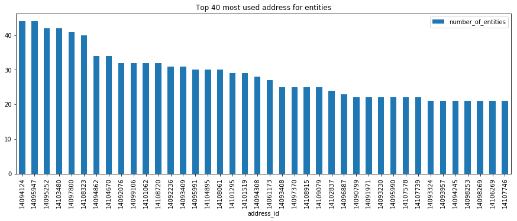

```python
fig, axes = plt.subplots(nrows=1, ncols=1, figsize=(15,5), squeeze=False)

entity_address_count = pd.DataFrame({'address_id':famous_adress,'number_of_entities':number_of_entities})
entity_address_count.set_index(['address_id'],inplace=True)
entity_address_count[:40].plot(kind='bar',title='Top 40 most used address for entities',ax=axes[0,0])
plt.show()
```

```python
panama_adress[panama_adress['n.node_id'].isin(entity_address_count[:2].index.tolist())]['n.address']
```

```
91248    CONSULTORES LEGALES; S. A. EDIFICIO PLAZA CORP...
91536    ETUDE DE MES REYMOND; ULMANN & FISCHELE (CHRIS...
Name: n.address, dtype: object
```

- **This address located in 'Guatemala'& 'Switzerland' register around 44 entities each!!**
- **Let's see those 44 entities located in Switzerland:** ETUDE DE MES REYMOND; ULMANN & FISCHELE (CHRIS...

```python
entities_44 = panama_entity[panama_entity['n.node_id'].isin(dict_entity_address[famous_adress[1]])]
entities_44.head()
```

|  | labels(n) | n.valid_until | n.country_codes | n.countries | n.node_id | n.sourceID | n.address | n.name | n.jurisdiction_description | n.service_provider | n.jurisdiction | n.closed_date | n.incorporation_date | n.ibcRUC | n.type | n.status | n.company_type | n.note |
| --- | --- | --- | --- | --- | --- | --- | --- | --- | --- | --- | --- | --- | --- | --- | --- | --- | --- | --- |
| 55162 | ["Entity"] | The Panama Papers data is current through 2015 | CHE | Switzerland | 10055798 | Panama Papers | ETUDE DE MES REYMOND; ULMANN & FISCHELE (CHRIS... | HASSIFA TRADING CORP. | Panama | Mossack Fonseca | PMA | NaN | 2008-08-29 | 29 | NaN | Active | NaN | NaN |
| 59771 | ["Entity"] | The Panama Papers data is current through 2015 | CHE | Switzerland | 10059898 | Panama Papers | ETUDE DE MES REYMOND; ULMANN & FISCHELE (CHRIS... | DIFESA TRADING LTD. | British Virgin Islands | Mossack Fonseca | BVI | NaN | 1993-07-23 | 91640 | NaN | Defaulted | NaN | NaN |
| 69195 | ["Entity"] | The Panama Papers data is current through 2015 | CHE | Switzerland | 10068722 | Panama Papers | ETUDE DE MES REYMOND; ULMANN & FISCHELE (CHRIS... | CONSULTING, TRADING & INVESTING LIMITED | British Virgin Islands | Mossack Fonseca | BVI | NaN | 1996-04-30 | 184016 | NaN | Dissolved | NaN | NaN |
| 97921 | ["Entity"] | The Panama Papers data is current through 2015 | CHE | Switzerland | 10096390 | Panama Papers | ETUDE DE MES REYMOND; ULMANN & FISCHELE (CHRIS... | REYDEL FINANCE LTD. | British Virgin Islands | Mossack Fonseca | BVI | NaN | 2002-01-02 | 475047 | NaN | Defaulted | NaN | NaN |
| 121994 | ["Entity"] | The Panama Papers data is current through 2015 | CHE | Switzerland | 10156808 | Panama Papers | ETUDE DE MES REYMOND; ULMANN & FISCHELE (CHRIS... | Riversource Corp. | Panama | Mossack Fonseca | PMA | NaN | 2011-09-29 | 86 | NaN | Active | NaN | NaN |

- All of them are provided by **Mossack Fonseca**
- Jurisdiction:
  - **Panama:** 36
  - **British Virgin Islands:** 8

```python
#pd.DataFrame(entities_44['n.incorporation_date'].sort_values()).set_index('n.incorporation_date').ix['2011-01-01':'2013-12-01']
```

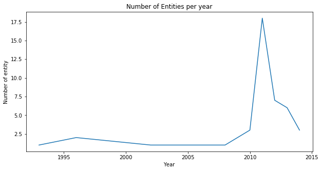

```python
plt.figure(figsize=(10,5))
plt.plot(entities_44['n.incorporation_date'].dt.year.astype(int).value_counts().sort_index())
plt.xlabel('Year')
plt.ylabel('Number of entity')
plt.title('Number of Entities per year')
plt.show()
```

- Just in 2011, 18 entities was registred in the same address by Mossack Fonseca:
  - **07/2011:** 4 entities registrations
  - **12/2011:** 5 entities registrations

```python
entities_44['n.name'].head()
```

```
55162                       HASSIFA TRADING CORP.
59771                         DIFESA TRADING LTD.
69195     CONSULTING, TRADING & INVESTING LIMITED
97921                         REYDEL FINANCE LTD.
121994                          Riversource Corp.
Name: n.name, dtype: object
```

- Most of this entities are for **Trading, Finance or Consulting**
- For Interractive Viz of this node please visit this link: https://offshoreleaks.icij.org/nodes/11011617

# Merging all data

```python
panama_nodes = pd.concat([panama_entity,panama_intermediary,panama_officer,panama_adress])
panama_nodes.to_csv('./Data/merged_data.csv')
```

```python
panama_nodes.head(n=50)
```

[output not shown]

- **node_id** that start with/refere to:
  - 10: Entity
  - 11: Intermediary
  - 12 & 15: Officer
  - 14: Adress

```python
panama_edges.head()
```

|  | node_1 | rel_type | node_2 | r.sourceID | r.valid_until | r.start_date | r.end_date |
| --- | --- | --- | --- | --- | --- | --- | --- |
| 0 | 10000035 | registered_address | 14095990 | Panama Papers | NaN | NaT | NaT |
| 1 | 10000044 | registered_address | 14091035 | Panama Papers | NaN | NaT | NaT |
| 2 | 10000055 | registered_address | 14095990 | Panama Papers | NaN | NaT | NaT |
| 3 | 10000064 | registered_address | 14091429 | Panama Papers | NaN | NaT | NaT |
| 4 | 10000089 | registered_address | 14098253 | Panama Papers | NaN | NaT | NaT |

## Some mining over morocco (draft)

```python
#panama_edges[panama_edges['rel_type'] == 'intermediary_of' ]
```

```python
morocco_nodes = panama_nodes[panama_nodes['n.countries']=='Morocco']
morocco_nodes.head(n=2)
```

|  | labels(n) | n.valid_until | n.country_codes | n.countries | n.node_id | n.sourceID | n.address | n.name | n.jurisdiction_description | n.service_provider | n.jurisdiction | n.closed_date | n.incorporation_date | n.ibcRUC | n.type | n.status | n.company_type | n.note |
| --- | --- | --- | --- | --- | --- | --- | --- | --- | --- | --- | --- | --- | --- | --- | --- | --- | --- | --- |
| 21216 | ["Entity"] | The Panama Papers data is current through 2015 | MAR | Morocco | 10021401 | Panama Papers | BASILEUS HOLDINGS OFFSHORE 183 AVENUE PRINCE H... | VINTAGE FINANCE S.A. | Seychelles | Mossack Fonseca | SEY | NaN | 2008-03-12 | 046746 | NaN | Active | NaN | NaN |
| 23581 | ["Entity"] | The Panama Papers data is current through 2015 | MAR | Morocco | 10023779 | Panama Papers | BASILEUS HOLDINGS OFFSHORE 183 AVENUE PRINCE H... | ORANGEGREEN International Trading Limited | Seychelles | Mossack Fonseca | SEY | NaN | 2009-01-20 | 058193 | NaN | Active | NaN | NaN |

```python
morocco_nodes[morocco_nodes['labels(n)']=='["Officer"]']['n.name'].unique()
```

```
array(['SAAD BEKKARI', 'Max Metral', 'VALLEY ELECTRIC HOLDING CORPORATION',
       'JAMAL BENSSY', 'MRS. SIMONE ROUGE POITEVIN',
       'BASILEUS HOLDING OFFSHORE SARL AU',
       'BASILEUS HOLDING OFFSHORE SARL',
       'Basileus Holding Offshore Sarl AU',
       'BASILEUS HOLDINGS OFFSHORE SARL', 'FREDERICK MORELAND JR',
       'Mr.Sandro Benati', 'Mr.David Houphouet-Boigny', 'CHARLES FLATHER',
       'NIZAR  AL NAKEEB', 'KARIM DAMIR', 'VIRGINIA WOOSTER',
       'Nizar Al-Nakeeb', 'MOISES LEVY', 'PANG YAN', 'TANG BIN',
       'Mrs. Hiba Isam Wasef Jaber', 'Mrs. Mona Isam Wasef Jaber',
       'Mrs. Farah Isam Wasef Jaber', 'Mrs. Maha Z. H. Alsaifi',
       'Mr. Osama Isam Wasef Jaber', 'DAKIR BERRADA', 'SOFIA AMOR SAADANI',
       'SOFIA SAADANI AMOR', 'MICHAEL E. BLOOM', 'QI DAFENG',
       'Easil Land Ltd.', 'YAN LEBAU', 'CATHERINE GUEZ',
       'JACQUELINE MATHIAS', 'SECURITIES HOUSE NOMINEES INC.',
       'Omar Mouline', 'MRS. BEN-BRAHIM', 'MRS. ZINA NIZAR AL-NAKEEB',
       'MRS ZINA NIZAR AL-NAKEEB', 'GHITA BENNIS', 'RITA BENNIS',
       'Safa Al Khorsan', 'SAFA AL-KHORSAN', 'Mr. Jean-Pierre AMZALLAG',
       'SAFA AL KHORSAN', 'Adil Jabrane', 'VALERIS PARRA', 'ANGEL PARRA',
       'GÉRARD AMOUR ADOLPHE PARET', 'ATLANTIC RENTALS SDN BHD',
       'PAUL SECONDY', 'ANDRE FERNAND MIKULOVIC', 'Jacqueline Mathias',
       'Mr. Alexis KUPERFIS', 'Mounir Guessous',
       'Mr. Abderrahim CHERKAOUI', 'Mrs. Leila Cherkaoui',
       'Mr. Benjamin COHEN', 'Mrs. Ghita Bennis',
       'Mr. Georgi Penev Kovachev'], dtype=object)
```

```python
panama_nodes[panama_nodes['n.name']=='Mounir Majidi']
```

|  | labels(n) | n.valid_until | n.country_codes | n.countries | n.node_id | n.sourceID | n.address | n.name | n.jurisdiction_description | n.service_provider | n.jurisdiction | n.closed_date | n.incorporation_date | n.ibcRUC | n.type | n.status | n.company_type | n.note |
| --- | --- | --- | --- | --- | --- | --- | --- | --- | --- | --- | --- | --- | --- | --- | --- | --- | --- | --- |
| 238394 | ["Officer"] | The Panama Papers data is current through 2015 | NaN | NaN | 15006301 | Panama Papers | NaN | Mounir Majidi | NaN | NaN | NaN | NaN | NaT | NaN | NaN | NaN | NaN | Record manually added from leaked documents |

# Evolution of the number of entities in France

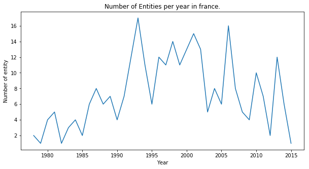

```
Only 0.14675592173017507% of the french data has an date
0.999836168400161% of the data has an date
```

```python
france_nodes = panama_nodes[panama_nodes['n.countries']=='France']
france_year = pd.DataFrame(france_nodes['n.incorporation_date'].dropna().dt.year.astype(int).value_counts())
plt.figure(figsize=(10,5))
plt.plot(france_year['n.incorporation_date'].sort_index())
plt.xlabel('Year')
plt.ylabel('Number of entity')
plt.title('Number of Entities per year in france.')
plt.show()

print('Only {}% of the french data has an date'.format(np.sum(france_year['n.incorporation_date']) / france_nodes.shape[0]))
panama_year = pd.DataFrame(panama_entity['n.incorporation_date'].dropna().dt.year.astype(int).value_counts())
print('{}% of the data has an date'.format(np.sum(panama_year['n.incorporation_date']) / panama_entity.shape[0]))
```

As we can see not enough data has an date to be consider a temproral analysis for France.

# Is there a correlation between the financial freedom and the number of entities coming from the same country in the dataset ?

To understand why entities are saving money in Panama, we gonna use this dataset: http://www.heritage.org/index. It contains differenct factors to determine how free a country is. We'll use the 2013 which is the oldest dataset on the webiste. It will represent the world status at this time before the leak. Our assumption here is that many accounts without date are recent accounts from the 2-4 previous year before the leak.

```python
heritage_df = pd.read_excel('./Data/index2013_data.xls')
heritage_df.head()
```

|  | CountryID | Country Name | WEBNAME | Region | World Rank | Region Rank | 2013 Score | Change in Yearly Score from 2012 | Property Rights | Change in Property Rights from 2012 | ... | Country | Population (Millions) | GDP (Billions, PPP) | GDP Growth Rate (%) | 5 Year GDP Growth Rate (%) | GDP per Capita (PPP) | Unemployment (%) | Inflation (%) | FDI Inflow (Millions) | Public Debt (% of GDP) |
| --- | --- | --- | --- | --- | --- | --- | --- | --- | --- | --- | --- | --- | --- | --- | --- | --- | --- | --- | --- | --- | --- |
| 0 | 1 | Afghanistan | Afghanistan | Asia-Pacific | NaN | NaN | NaN | NaN | NaN | NaN | ... | Afghanistan | 31.084 | 29.731 | 5.737 | 10.335398 | 956.448 | NaN | 11.247 | 83.411455 | 12.100 |
| 1 | 2 | Albania | Albania | Europe | 58.0 | 27.0 | 65.2 | 0.1 | 30.0 | -5.0 | ... | Albania | 3.218 | 24.910 | 2.000 | 4.431419 | 7741.428 | 13.5 | 3.427 | 1031.362818 | 58.923 |
| 2 | 3 | Algeria | Algeria | Middle East / North Africa | 145.0 | 14.0 | 49.6 | -1.4 | 30.0 | 0.0 | ... | Algeria | 35.954 | 263.661 | 2.470 | 2.718594 | 7333.226 | 10.0 | 4.500 | 2571.000000 | 9.925 |
| 3 | 4 | Angola | Angola | Sub-Saharan Africa | 158.0 | 40.0 | 47.3 | 0.6 | 15.0 | -5.0 | ... | Angola | 19.625 | 115.679 | 3.404 | 8.848807 | 5894.617 | NaN | 13.500 | -5585.529270 | 30.897 |
| 4 | 5 | Argentina | Argentina | South and Central America / Caribbean | 160.0 | 27.0 | 46.7 | -1.3 | 15.0 | -5.0 | ... | Argentina | 40.900 | 716.419 | 8.870 | 6.811779 | 17516.147 | 7.2 | 9.775 | 7243.148181 | 44.203 |

5 rows × 43 columns